# Getting started

You can execute R scripts in three ways:

- from the Command line (R command)
- from the R gui (R.app on the mac, offers a simple development environment)
- from the development environment of Rstudio.

We will focus on this last option.

##### Let’s explore built-in data sets:

R and its various packages come with many built-in data sets The data() function lists them. Entering a function name without brackets lists its content, in this case the source code of the function “data”.

```r
data() # list data sets
cars # let's look at the content of the cars data set
```

| speed | dist |
| --- | --- |
| 4 | 2 |
| 4 | 10 |
| 7 | 4 |
| 7 | 22 |
| 8 | 16 |
| 9 | 10 |
| 10 | 18 |
| 10 | 26 |
| 10 | 34 |
| 11 | 17 |

[output cut: 40 more lines]

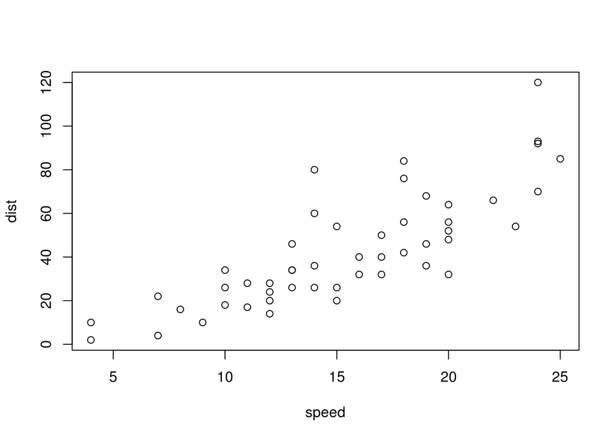

```r
# more information about the data set:
??cars

plot(cars) # plots the data set using the generic plot function
```

We can investigate the structure of the data set. You can access the same information in the Environment tab of the GUI.

```r
str(cars) # function to display the structure of the data set
```

```
## 'data.frame':    50 obs. of  2 variables:
##  $ speed: num  4 4 7 7 8 9 10 10 10 11 ...
##  $ dist : num  2 10 4 22 16 10 18 26 34 17 ...
```

The data set is a “data frame”, a rectangular composite data structure, similar to an excel table. It consists of two variables, in this case vectors, with each 50 elements. We can look at them individually:

```r
cars$speed
```

```
##  [1]  4  4  7  7  8  9 10 10 10 11 11 12 12 12 12 13 13 13 13 14 14 14 14
## [24] 15 15 15 16 16 17 17 17 18 18 18 18 19 19 19 20 20 20 20 20 22 23 24
## [47] 24 24 24 25
```

```r
cars$dist
```

```
##  [1]   2  10   4  22  16  10  18  26  34  17  28  14  20  24  28  26  34
## [18]  34  46  26  36  60  80  20  26  54  32  40  32  40  50  42  56  76
## [35]  84  36  46  68  32  48  52  56  64  66  54  70  92  93 120  85
```

```r
summary(cars)
```

```
##      speed           dist
##  Min.   : 4.0   Min.   :  2.00
##  1st Qu.:12.0   1st Qu.: 26.00
##  Median :15.0   Median : 36.00
##  Mean   :15.4   Mean   : 42.98
##  3rd Qu.:19.0   3rd Qu.: 56.00
##  Max.   :25.0   Max.   :120.00
```

```r
mean(cars$speed)
```

```
## [1] 15.4
```

```r
median(cars$dist)
```

```
## [1] 36
```